# Generalized Ideal Point Models for Time-Varying and Missing-data Inference

Robert Kubinec New York University Abu Dhabi

July 20, 2019

## Broad Overview

- Ideal point models are widely used but generally for only a single empirical application: ideology.
- It can be difficult to use ideal point models outside of their original domain of scaling rollcall matrices.
- The growth in the number and size of datasets amenable to scaling creates a demand for better software.

## Required Meme

[figure not shown]

## Ideal Point Models

- Ideal point models are based on a very simple social choice model: pick A if A is closer to your ideal point than B.
- Particular formulations vary, including DW-NOMINATE, latent space model, and the CJR item-response theory formulation:

$$Y_{ij} = \alpha_i\gamma_j - \beta_j$$

For $i$ rows and $j$ columns where $i$ are the “persons” and $j$ are the items, such as bills.

## Advantages of Ideal Point Models

- Ideal point models compress data down to a uni- or multi-dimensional representation of the social choice process.
- Widely applicable when people choose based on some latent construct.
- Interpreted as ideology in the legislature, but could be anything: think of it as a way of estimating social preferences.
- Two pieces of information:
  - value of $\alpha_i$ is the person’s score on the latent scale
  - value of $\gamma_j$ is the discrimination, or relative predictive power, of the item vis-a-vis the latent scale

## Extension 1: Missing Data

People can either be absent $r=0$ or show up to vote $r=1$:

$$\begin{equation}
\scriptstyle
L(Y_{ijr}|\alpha_i,\gamma_j,\beta_j,\nu_j,\omega_j) =
\prod^{I}_{i=1} \prod^{J}_{j=1}
\begin{cases}
\scriptstyle
\zeta(\alpha_{i}'\nu_j - \omega_j ) & \text{if } r=0, \text{ and} \\
(1-\zeta({\alpha_{i}'\nu_j - \omega_j}))L(Y_{ij}|\alpha_i,\gamma_j,\beta_j) & \text{if } r=1
\end{cases}
\end{equation}$$

where $Pr(r=0)=\zeta(\alpha_{i}'\nu_j - \omega_j )$

## Extension 2: Random Walk

Standard random walk model:

$$\alpha_{it} \sim N(\alpha_{it-1},\sigma_i)$$

## Extension 2: AR(1)

Auto-regressive (AR(1)) model:

$$\alpha_{it} \sim N(\psi_i\alpha_{it-1},\sigma_i)$$

## Extension 3: Gaussian Processes

Gaussian process model:

$$\alpha_{it} \sim N(0,k_t(\alpha_{it},\alpha_{it'}))$$
Where $k(\cdot)$ is the squared exponential kernel:

$$k_t(\alpha_{it},\alpha_{it'}) = \large \sigma^2_{if} e^{\displaystyle -\frac{(\alpha_{it} - \alpha_{it'})^2}{ 2l_i^2}} + \sigma^2_{\alpha}$$

## Variance Issues with Time Series

[figure not shown]

## Extension 4: Joint Distributions

- We can allow different likelihoods $L_m$ for any of the following distributions $M$:
  - Ordinal (graded response)
  - Ordinal (rating scale)
  - Count (poisson)
  - Continuous (Normal)
  - Positive-continuous (Log-Normal)
- Important for fitting “index” models with mixed data from surveys or panel data (VDEM, etc)

## Bayesian Estimation

[figure not shown]

## Idealstan

- Package exploits Stan to expand range of ideal point models that exist.
- Markov Chain Monte Carlo inference on all models
- Probalistic programming (graphical models) permits easy extension + flexibility
- Wide range of posterior-predictive checks and plotting functions

## Extension 4: Big Data

- All models can be estimated with black-box variational inference
  - Generally accurate if strict thresholds are used for convergence
  - Understates posterior uncertainty, lacks as strong diagnostics
- Alternative: parallelize likelihood within an MCMC chain
  - Very powerful as can speed up computation per cores
  - All models can be implemented in this parallelization scheme (coming soon)

## Empirical Example

- I collected county-level monthly unemployment data from the Bureau of Labor Statistics.
- Aggregated to the Congressional district level with spatial joins.
- Assign rollcall votes to each month’s unemployment.
- Fit the following ideal-point regression (hierarchical covariates):

$$\alpha_{it} \sim N(\psi_i\alpha_{it-1} + X_t\phi',\sigma_i)$$

## Unemployment Data

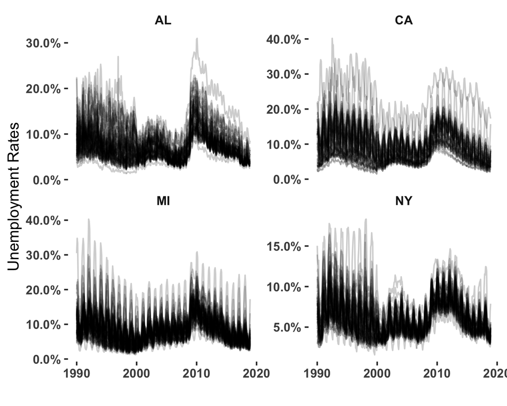

## Ideal Point Distribution

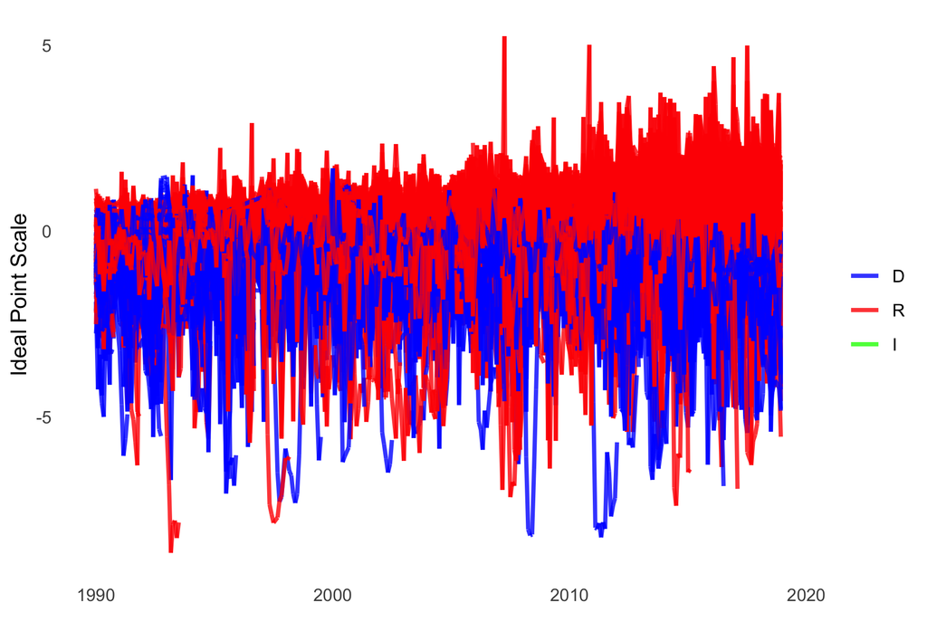

## How to Interpret Covariates

For each posterior draw $s \in S$ and item $j \in J$, average the value of covariate over distribution of positive or negative discrimination scores $\gamma_j$ and convert to probabilities:

$$\frac{\partial \phi}{\partial Pr(Y_{ijrt}=1|\gamma_j>0)} = \frac{ \sum_{j=1}^J \Theta(X\phi_s' \gamma_{js})-0.5}{J}$$
$$\frac{\partial \phi}{\partial Pr(Y_{ijrt}=1|\gamma_j<0)} = \frac{ \sum_{j=1}^J \Theta(X\phi_s' \gamma_{js})-0.5}{J}$$

## Overall Results

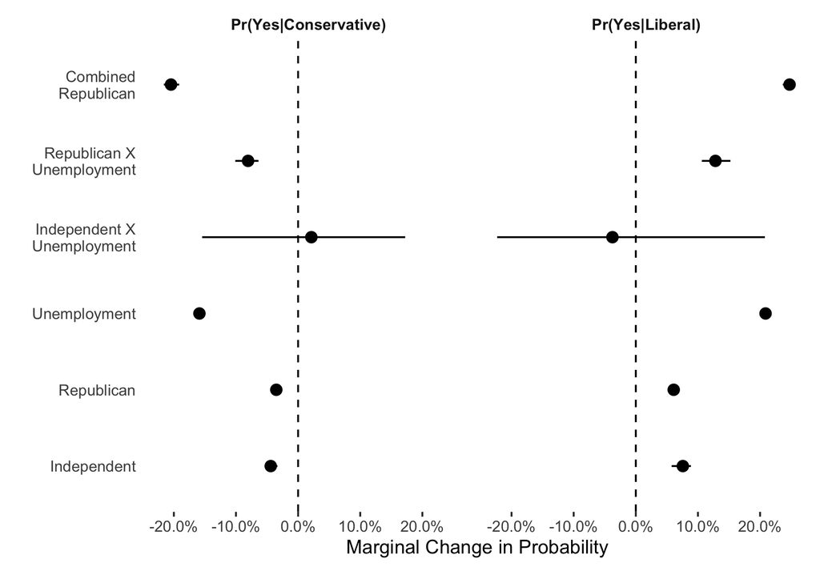

## Impulse Response Functions

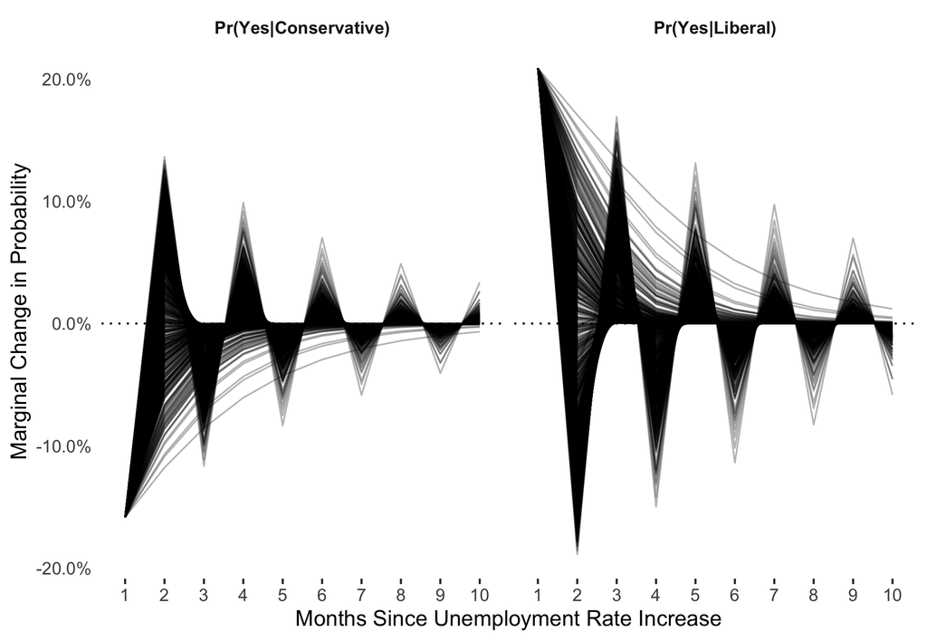

## China X Unemployment Interaction

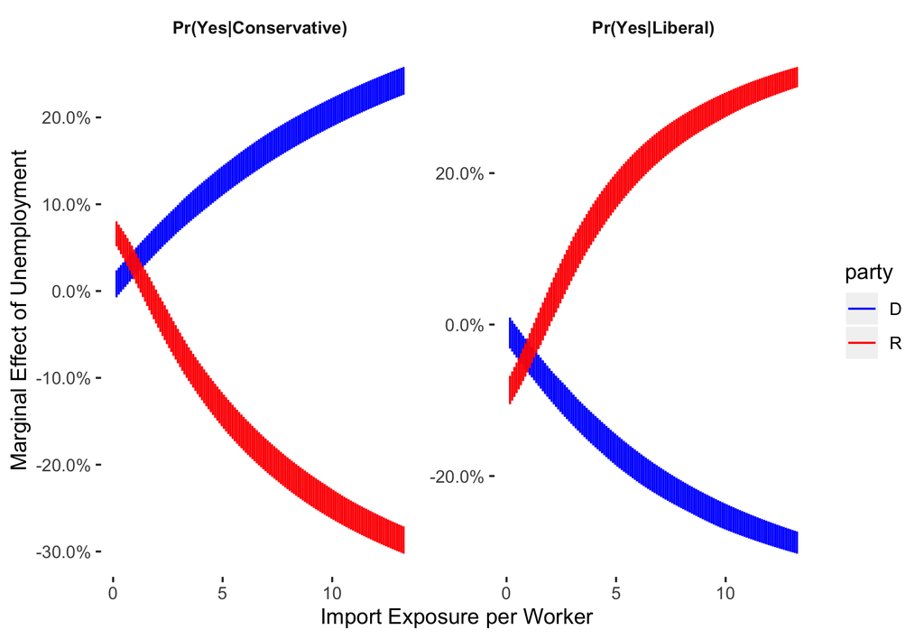

## Future Research

- Likelihood parallelization will permit true scalable Bayesian inference.
- More empirical applications are possible (Twitter data & selection model, index creation with joint likelihoods).
- Possible to further extend ideal point models in new directions, including latent space parameterization.